This work will present the analysis for an anonymous subject about his/her daily movement activities.

## Preparing the data

A couple of packages for the work are loaded at first

```r
library(lubridate)
library(dplyr)
library(xtable)
```

First, we need to unzip the dataset -if wasn’t made previously-

```r
if(!file.exists("activity.csv")){
        unzip(zipfile = "activity.zip")
}
```

Then, the data is loaded

```r
activity <- read.csv("activity.csv", header=TRUE)
```

It’s important to check how the data is looking reviewing the head of dataset and the class of the columns

```r
str(activity)
```

```
## 'data.frame':    17568 obs. of  3 variables:
##  $ steps   : int  NA NA NA NA NA NA NA NA NA NA ...
##  $ date    : Factor w/ 61 levels "2012-10-01","2012-10-02",..: 1 1 1 1 1 1 1 1 1 1 ...
##  $ interval: int  0 5 10 15 20 25 30 35 40 45 ...
```

I’m not happy with the class of data, so, I will change them

```r
activity$date <- ymd(activity$date)
activity$interval <- as.factor(activity$interval)
```

## What is mean total number of steps taken per day?

To solve this question I group the data by date and then summarize the mean

```r
meansteps <- group_by(activity[complete.cases(activity),],date) %>%
                summarize(daily.steps=sum(steps),
                mean_day=mean(steps,na.rm = TRUE),
                median.day=median(steps))
htmltable <- xtable(meansteps)
```

And the histogram of the total steps

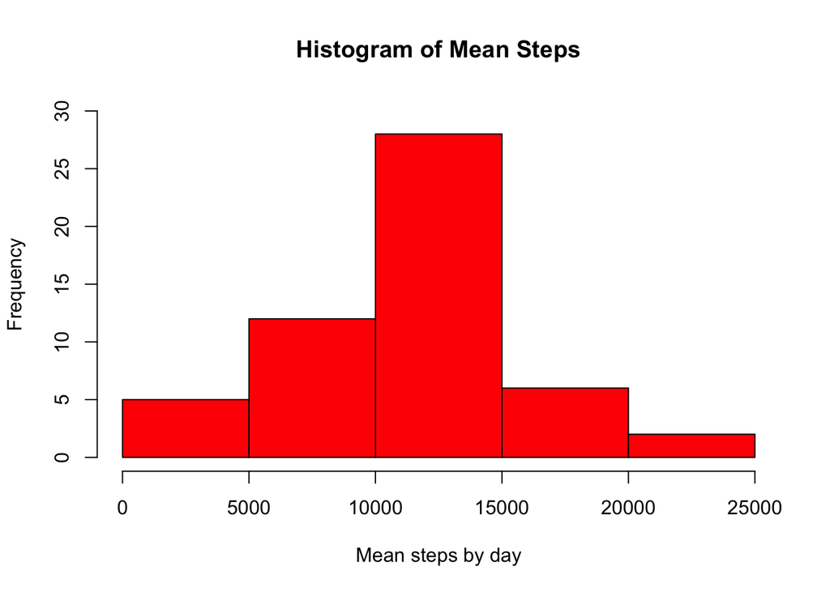

```r
hist(meansteps$daily.steps, main="Histogram of Mean Steps", ylim=c(0,30),
     xlab = "Mean steps by day", col=2)
```

**Summary of data**

```r
print(htmltable, type="html")
```

|  | date | daily.steps | mean_day | median.day |
| --- | --- | --- | --- | --- |
| 1 | 15615.00 | 126 | 0.44 | 0.00 |
| 2 | 15616.00 | 11352 | 39.42 | 0.00 |
| 3 | 15617.00 | 12116 | 42.07 | 0.00 |
| 4 | 15618.00 | 13294 | 46.16 | 0.00 |
| 5 | 15619.00 | 15420 | 53.54 | 0.00 |
| 6 | 15620.00 | 11015 | 38.25 | 0.00 |
| 7 | 15622.00 | 12811 | 44.48 | 0.00 |
| 8 | 15623.00 | 9900 | 34.38 | 0.00 |
| 9 | 15624.00 | 10304 | 35.78 | 0.00 |
| 10 | 15625.00 | 17382 | 60.35 | 0.00 |
| 11 | 15626.00 | 12426 | 43.15 | 0.00 |
| 12 | 15627.00 | 15098 | 52.42 | 0.00 |
| 13 | 15628.00 | 10139 | 35.20 | 0.00 |
| 14 | 15629.00 | 15084 | 52.38 | 0.00 |
| 15 | 15630.00 | 13452 | 46.71 | 0.00 |
| 16 | 15631.00 | 10056 | 34.92 | 0.00 |
| 17 | 15632.00 | 11829 | 41.07 | 0.00 |
| 18 | 15633.00 | 10395 | 36.09 | 0.00 |
| 19 | 15634.00 | 8821 | 30.63 | 0.00 |
| 20 | 15635.00 | 13460 | 46.74 | 0.00 |
| 21 | 15636.00 | 8918 | 30.97 | 0.00 |
| 22 | 15637.00 | 8355 | 29.01 | 0.00 |
| 23 | 15638.00 | 2492 | 8.65 | 0.00 |
| 24 | 15639.00 | 6778 | 23.53 | 0.00 |
| 25 | 15640.00 | 10119 | 35.14 | 0.00 |
| 26 | 15641.00 | 11458 | 39.78 | 0.00 |
| 27 | 15642.00 | 5018 | 17.42 | 0.00 |
| 28 | 15643.00 | 9819 | 34.09 | 0.00 |
| 29 | 15644.00 | 15414 | 53.52 | 0.00 |
| 30 | 15646.00 | 10600 | 36.81 | 0.00 |
| 31 | 15647.00 | 10571 | 36.70 | 0.00 |
| 32 | 15649.00 | 10439 | 36.25 | 0.00 |
| 33 | 15650.00 | 8334 | 28.94 | 0.00 |
| 34 | 15651.00 | 12883 | 44.73 | 0.00 |
| 35 | 15652.00 | 3219 | 11.18 | 0.00 |
| 36 | 15655.00 | 12608 | 43.78 | 0.00 |
| 37 | 15656.00 | 10765 | 37.38 | 0.00 |
| 38 | 15657.00 | 7336 | 25.47 | 0.00 |
| 39 | 15659.00 | 41 | 0.14 | 0.00 |
| 40 | 15660.00 | 5441 | 18.89 | 0.00 |
| 41 | 15661.00 | 14339 | 49.79 | 0.00 |
| 42 | 15662.00 | 15110 | 52.47 | 0.00 |
| 43 | 15663.00 | 8841 | 30.70 | 0.00 |
| 44 | 15664.00 | 4472 | 15.53 | 0.00 |
| 45 | 15665.00 | 12787 | 44.40 | 0.00 |
| 46 | 15666.00 | 20427 | 70.93 | 0.00 |
| 47 | 15667.00 | 21194 | 73.59 | 0.00 |
| 48 | 15668.00 | 14478 | 50.27 | 0.00 |
| 49 | 15669.00 | 11834 | 41.09 | 0.00 |
| 50 | 15670.00 | 11162 | 38.76 | 0.00 |
| 51 | 15671.00 | 13646 | 47.38 | 0.00 |
| 52 | 15672.00 | 10183 | 35.36 | 0.00 |
| 53 | 15673.00 | 7047 | 24.47 | 0.00 |

**Table**

```r
summary(meansteps)
```

```
##       date             daily.steps       mean_day         median.day
##  Min.   :2012-10-02   Min.   :   41   Min.   : 0.1424   Min.   :0
##  1st Qu.:2012-10-16   1st Qu.: 8841   1st Qu.:30.6979   1st Qu.:0
##  Median :2012-10-29   Median :10765   Median :37.3785   Median :0
##  Mean   :2012-10-30   Mean   :10766   Mean   :37.3826   Mean   :0
##  3rd Qu.:2012-11-16   3rd Qu.:13294   3rd Qu.:46.1597   3rd Qu.:0
##  Max.   :2012-11-29   Max.   :21194   Max.   :73.5903   Max.   :0
```

## What is the average daily activity pattern?

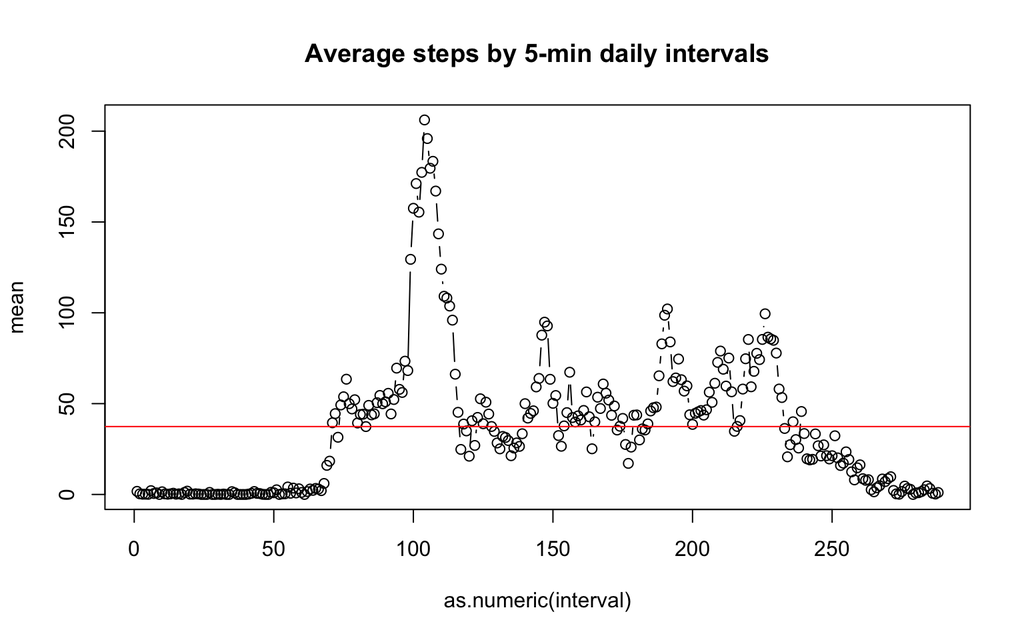

```r
intervalsteps <- group_by(activity[complete.cases(activity),],interval) %>%
                summarize(mean=mean(steps,na.rm = TRUE))
with(intervalsteps, plot(as.numeric(interval),mean, type="b", main="Average steps by 5-min daily intervals"),
     ylab="Average steps", xlab="5-min time interval")
abline(h = mean(intervalsteps$mean), col=2)
```

**Now we subset the max value interval**

```r
intervalsteps[intervalsteps$mean==max(intervalsteps$mean),]
```

```
## # A tibble: 1 x 2
##   interval     mean
##     <fctr>    <dbl>
## 1      835 206.1698
```

That’s means that the max average of steps is during the 8:35 interval

## Imputing missing values

**How many NA’s we have**

```r
sum(is.na(activity$steps))
```

```
## [1] 2304
```

It’s better as percentage

```r
sum(is.na(activity$steps))/nrow(activity)
```

```
## [1] 0.1311475
```

We have a 13% missing values

**Imputate**

In this step, I will imputate the mean of the interval assigned to the missing data using function impute

```r
impute <- function (x)
{
        if(is.na(x[1])){
        ##Mean of the interval
        intmean <- intervalsteps[intervalsteps$interval==x[3],]

        x[1] <- round(intmean$mean,2)
        }
        x
}
```

Now, I create the new data.frame

```r
complete_activity <- apply(activity,1,impute)
complete_activity <- t(complete_activity) # Transpose de new matrix
complete_activity <- tbl_df(complete_activity) # Convert to a data.frame

# Change classes
complete_activity$steps <- as.integer(complete_activity$steps)
complete_activity$date <- ymd(complete_activity$date)
complete_activity$interval <- as.factor(complete_activity$interval)
str(complete_activity)
```

```
## Classes 'tbl_df', 'tbl' and 'data.frame':    17568 obs. of  3 variables:
##  $ steps   : int  1 0 0 0 0 2 0 0 0 1 ...
##  $ date    : Date, format: "2012-10-01" "2012-10-01" ...
##  $ interval: Factor w/ 288 levels "0","10","100",..: 1 226 2 73 136 195 198 209 212 223 ...
```

Verify NA’s in the new dataframe

```r
sum(is.na(complete_activity))
```

```
## [1] 0
```

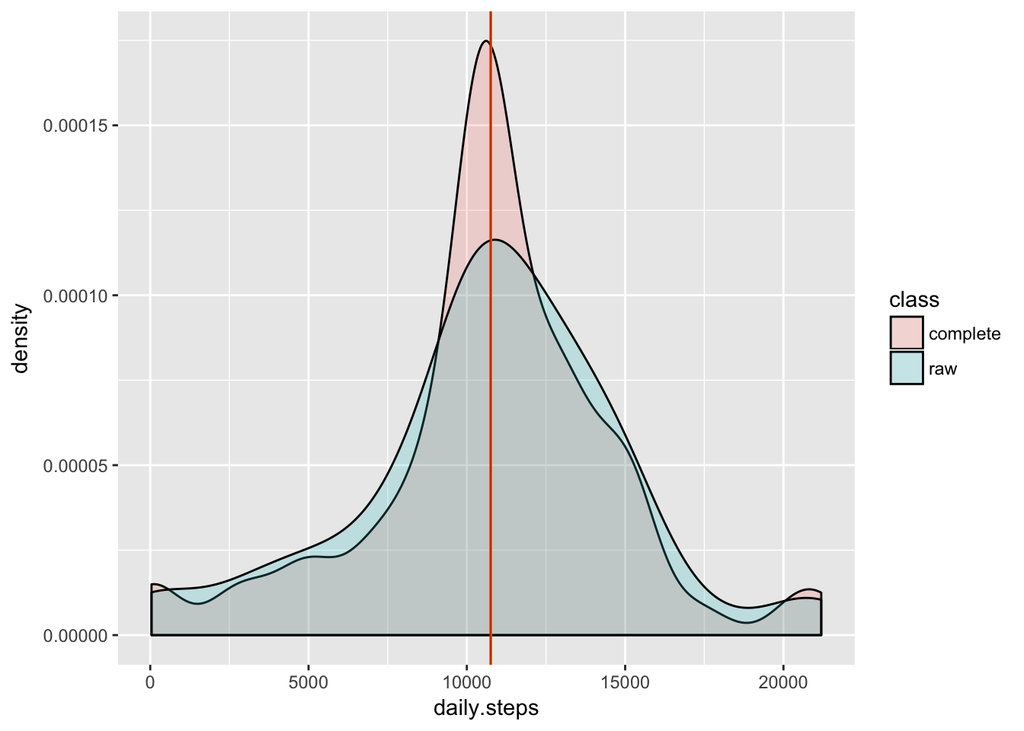

```r
complete_meansteps <- group_by(complete_activity,date) %>%
                summarize(daily.steps=sum(steps),
                mean_day=mean(steps,na.rm = TRUE),
                median.day=median(steps))
htmltable2 <- xtable(complete_meansteps)

meansteps$class <- "raw"
complete_meansteps$class <- "complete"

allcases <- rbind(meansteps,complete_meansteps)

library(ggplot2)
ggplot(allcases, aes(daily.steps, fill = class)) + geom_density(alpha = 0.2) +
        geom_vline(aes(xintercept = mean(meansteps$daily.steps)), colour="green") +
        geom_vline(aes(xintercept = mean(complete_meansteps$daily.steps)), colour="red")
```

```r
print(htmltable2, type="html")
```

|  | date | daily.steps | mean_day | median.day |
| --- | --- | --- | --- | --- |
| 1 | 15614.00 | 10641 | 36.95 | 33.50 |
| 2 | 15615.00 | 126 | 0.44 | 0.00 |
| 3 | 15616.00 | 11352 | 39.42 | 0.00 |
| 4 | 15617.00 | 12116 | 42.07 | 0.00 |
| 5 | 15618.00 | 13294 | 46.16 | 0.00 |
| 6 | 15619.00 | 15420 | 53.54 | 0.00 |
| 7 | 15620.00 | 11015 | 38.25 | 0.00 |
| 8 | 15621.00 | 10641 | 36.95 | 33.50 |
| 9 | 15622.00 | 12811 | 44.48 | 0.00 |
| 10 | 15623.00 | 9900 | 34.38 | 0.00 |
| 11 | 15624.00 | 10304 | 35.78 | 0.00 |
| 12 | 15625.00 | 17382 | 60.35 | 0.00 |
| 13 | 15626.00 | 12426 | 43.15 | 0.00 |
| 14 | 15627.00 | 15098 | 52.42 | 0.00 |
| 15 | 15628.00 | 10139 | 35.20 | 0.00 |
| 16 | 15629.00 | 15084 | 52.38 | 0.00 |
| 17 | 15630.00 | 13452 | 46.71 | 0.00 |
| 18 | 15631.00 | 10056 | 34.92 | 0.00 |
| 19 | 15632.00 | 11829 | 41.07 | 0.00 |
| 20 | 15633.00 | 10395 | 36.09 | 0.00 |
| 21 | 15634.00 | 8821 | 30.63 | 0.00 |
| 22 | 15635.00 | 13460 | 46.74 | 0.00 |
| 23 | 15636.00 | 8918 | 30.97 | 0.00 |
| 24 | 15637.00 | 8355 | 29.01 | 0.00 |
| 25 | 15638.00 | 2492 | 8.65 | 0.00 |
| 26 | 15639.00 | 6778 | 23.53 | 0.00 |
| 27 | 15640.00 | 10119 | 35.14 | 0.00 |
| 28 | 15641.00 | 11458 | 39.78 | 0.00 |
| 29 | 15642.00 | 5018 | 17.42 | 0.00 |
| 30 | 15643.00 | 9819 | 34.09 | 0.00 |
| 31 | 15644.00 | 15414 | 53.52 | 0.00 |
| 32 | 15645.00 | 10641 | 36.95 | 33.50 |
| 33 | 15646.00 | 10600 | 36.81 | 0.00 |
| 34 | 15647.00 | 10571 | 36.70 | 0.00 |
| 35 | 15648.00 | 10641 | 36.95 | 33.50 |
| 36 | 15649.00 | 10439 | 36.25 | 0.00 |
| 37 | 15650.00 | 8334 | 28.94 | 0.00 |
| 38 | 15651.00 | 12883 | 44.73 | 0.00 |
| 39 | 15652.00 | 3219 | 11.18 | 0.00 |
| 40 | 15653.00 | 10641 | 36.95 | 33.50 |
| 41 | 15654.00 | 10641 | 36.95 | 33.50 |
| 42 | 15655.00 | 12608 | 43.78 | 0.00 |
| 43 | 15656.00 | 10765 | 37.38 | 0.00 |
| 44 | 15657.00 | 7336 | 25.47 | 0.00 |
| 45 | 15658.00 | 10641 | 36.95 | 33.50 |
| 46 | 15659.00 | 41 | 0.14 | 0.00 |
| 47 | 15660.00 | 5441 | 18.89 | 0.00 |
| 48 | 15661.00 | 14339 | 49.79 | 0.00 |
| 49 | 15662.00 | 15110 | 52.47 | 0.00 |
| 50 | 15663.00 | 8841 | 30.70 | 0.00 |
| 51 | 15664.00 | 4472 | 15.53 | 0.00 |
| 52 | 15665.00 | 12787 | 44.40 | 0.00 |
| 53 | 15666.00 | 20427 | 70.93 | 0.00 |
| 54 | 15667.00 | 21194 | 73.59 | 0.00 |
| 55 | 15668.00 | 14478 | 50.27 | 0.00 |
| 56 | 15669.00 | 11834 | 41.09 | 0.00 |
| 57 | 15670.00 | 11162 | 38.76 | 0.00 |
| 58 | 15671.00 | 13646 | 47.38 | 0.00 |
| 59 | 15672.00 | 10183 | 35.36 | 0.00 |
| 60 | 15673.00 | 7047 | 24.47 | 0.00 |
| 61 | 15674.00 | 10641 | 36.95 | 33.50 |

**Table**

```r
summary(complete_meansteps)
```

```
##       date             daily.steps       mean_day         median.day
##  Min.   :2012-10-01   Min.   :   41   Min.   : 0.1424   Min.   : 0.000
##  1st Qu.:2012-10-16   1st Qu.: 9819   1st Qu.:34.0938   1st Qu.: 0.000
##  Median :2012-10-31   Median :10641   Median :36.9479   Median : 0.000
##  Mean   :2012-10-31   Mean   :10750   Mean   :37.3256   Mean   : 4.393
##  3rd Qu.:2012-11-15   3rd Qu.:12811   3rd Qu.:44.4826   3rd Qu.: 0.000
##  Max.   :2012-11-30   Max.   :21194   Max.   :73.5903   Max.   :33.500
##     class
##  Length:61
##  Class :character
##  Mode  :character
##
##
##
```

## Are there differences in activity patterns between weekdays and weekends?

I will work with the impute dataset

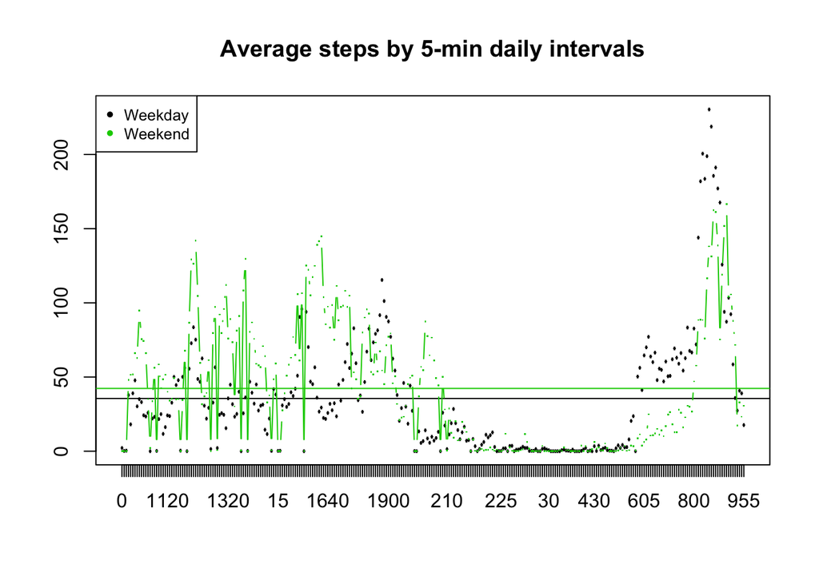

```r
# Create the new column
complete_activity <- mutate(complete_activity,weekday=weekdays(complete_activity$date))

# Reassing the levels
for(i in 1:nrow(complete_activity)){
        if(complete_activity[i,"weekday"]=="Saturday" | complete_activity[i,"weekday"]=="Sunday"){
                complete_activity[i,"week"] <- "weekend"
        }else{
                complete_activity[i,"week"] <- "weekday"
        }
}

#weekday points
weekday_int <- filter(complete_activity, week=="weekday") %>%
                group_by(interval) %>%
                summarize(mean=mean(steps,na.rm = TRUE))
with(weekday_int, plot(interval,mean, type="b",  pch=".", col=1, main="Average steps by 5-min daily intervals"),
     ylab="Average steps", xlab="5-min time interval")
abline(h = mean(weekday_int$mean), col=1)

#Weekend points
weekend_end <- filter(complete_activity, week=="weekend") %>%
                group_by(interval) %>%
                summarize(mean=mean(steps,na.rm = TRUE))
with(weekend_end, points(interval,mean, type="b", pch=".", col=3))
abline(h = mean(weekend_end$mean), col=3)
legend("topleft",legend = c("Weekday","Weekend"),col=c(1,3),pch=20, cex=0.8)
```